# Project 3: Organic Products

Yanghua Zhang

```python
# import libraries
from IPython.core.display import display, HTML
from IPython.display import clear_output
display(HTML("<style>.container { width:90% }</style>"))
import warnings
warnings.filterwarnings('ignore')
# ------------------------------------------------------------------

import numpy as np
import matplotlib.pyplot as plt
import seaborn as sns
import pandas as pd
import statsmodels.api as sm

from sklearn.model_selection import train_test_split
from sklearn.linear_model import LogisticRegression
from sklearn.metrics import accuracy_score, precision_score, recall_score
from sklearn.feature_selection import chi2, SelectKBest
from sklearn.metrics import confusion_matrix, roc_curve, roc_auc_score
from sklearn.feature_selection import SelectFromModel
from sklearn.tree import DecisionTreeClassifier
```

```python
# import google drive
from google.colab import drive
drive.mount('/content/drive')
```

# Load Data

```python
# load the data into a pandas dataframe

data_path = '/content/drive/My Drive/Data/organics-1.csv'
df = pd.read_csv(data_path)

# preview data
df.info()
df.head()
```

```
<class 'pandas.core.frame.DataFrame'>
RangeIndex: 22223 entries, 0 to 22222
Data columns (total 13 columns):
 #   Column           Non-Null Count  Dtype
---  ------           --------------  -----
 0   ID               22223 non-null  int64
 1   DemAffl          21138 non-null  float64
 2   DemAge           20715 non-null  float64
 3   DemCluster       21549 non-null  float64
 4   DemClusterGroup  21549 non-null  object
 5   DemGender        19711 non-null  object
 6   DemReg           21758 non-null  object
 7   DemTVReg         21758 non-null  object
 8   PromClass        22223 non-null  object
 9   PromSpend        22223 non-null  float64
 10  PromTime         21942 non-null  float64
 11  TargetBuy        22223 non-null  int64
 12  TargetAmt        22223 non-null  int64
dtypes: float64(5), int64(3), object(5)
memory usage: 2.2+ MB
```

|  | ID | DemAffl | DemAge | DemCluster | DemClusterGroup | DemGender | DemReg | DemTVReg | PromClass | PromSpend | PromTime | TargetBuy | TargetAmt |
| --- | --- | --- | --- | --- | --- | --- | --- | --- | --- | --- | --- | --- | --- |
| 0 | 140 | 10.0 | 76.0 | 16.0 | C | U | Midlands | Wales & West | Gold | 16000.00 | 4.0 | 0 | 0 |
| 1 | 620 | 4.0 | 49.0 | 35.0 | D | U | Midlands | Wales & West | Gold | 6000.00 | 5.0 | 0 | 0 |
| 2 | 868 | 5.0 | 70.0 | 27.0 | D | F | Midlands | Wales & West | Silver | 0.02 | 8.0 | 1 | 1 |
| 3 | 1120 | 10.0 | 65.0 | 51.0 | F | M | Midlands | Midlands | Tin | 0.01 | 7.0 | 1 | 1 |
| 4 | 2313 | 11.0 | 68.0 | 4.0 | A | F | Midlands | Midlands | Tin | 0.01 | 8.0 | 0 | 0 |

```python
# check for missing values
print(df.isnull().sum())
```

```
ID                    0
DemAffl            1085
DemAge             1508
DemCluster          674
DemClusterGroup     674
DemGender          2512
DemReg              465
DemTVReg            465
PromClass             0
PromSpend             0
PromTime            281
TargetBuy             0
TargetAmt             0
dtype: int64
```

```python
# Filling Missing Values
# For numerical columns
df['DemAffl'].fillna(df['DemAffl'].mean(), inplace=True)
df['DemAge'].fillna(df['DemAge'].median(), inplace=True)
df['DemCluster'].fillna(df['DemCluster'].mean(), inplace=True)
df['PromTime'].fillna(df['PromTime'].mean(), inplace=True)

#For categorical columns
df['DemClusterGroup'].fillna(df['DemClusterGroup'].mode()[0], inplace=True)
df['DemGender'].fillna(df['DemGender'].mode()[0], inplace=True)
df['DemReg'].fillna(df['DemReg'].mode()[0], inplace=True)
df['DemTVReg'].fillna(df['DemTVReg'].mode()[0], inplace=True)
df.info()
print(df.isnull().sum())
```

```
<class 'pandas.core.frame.DataFrame'>
RangeIndex: 22223 entries, 0 to 22222
Data columns (total 13 columns):
 #   Column           Non-Null Count  Dtype
---  ------           --------------  -----
 0   ID               22223 non-null  int64
 1   DemAffl          22223 non-null  float64
 2   DemAge           22223 non-null  float64
 3   DemCluster       22223 non-null  float64
 4   DemClusterGroup  22223 non-null  object
 5   DemGender        22223 non-null  object
 6   DemReg           22223 non-null  object
 7   DemTVReg         22223 non-null  object
 8   PromClass        22223 non-null  object
 9   PromSpend        22223 non-null  float64
 10  PromTime         22223 non-null  float64
 11  TargetBuy        22223 non-null  int64
 12  TargetAmt        22223 non-null  int64
dtypes: float64(5), int64(3), object(5)
memory usage: 2.2+ MB
ID                 0
DemAffl            0
DemAge             0
DemCluster         0
DemClusterGroup    0
DemGender          0
DemReg             0
DemTVReg           0
PromClass          0
PromSpend          0
PromTime           0
TargetBuy          0
TargetAmt          0
dtype: int64
```

# Preprocess

```python
# Convert response from an integer to a categorical variable
df['TargetBuy'] = df['TargetBuy'].astype('category')
df.head()
```

|  | ID | DemAffl | DemAge | DemCluster | DemClusterGroup | DemGender | DemReg | DemTVReg | PromClass | PromSpend | PromTime | TargetBuy | TargetAmt |
| --- | --- | --- | --- | --- | --- | --- | --- | --- | --- | --- | --- | --- | --- |
| 0 | 140 | 10.0 | 76.0 | 16.0 | C | U | Midlands | Wales & West | Gold | 16000.00 | 4.0 | 0 | 0 |
| 1 | 620 | 4.0 | 49.0 | 35.0 | D | U | Midlands | Wales & West | Gold | 6000.00 | 5.0 | 0 | 0 |
| 2 | 868 | 5.0 | 70.0 | 27.0 | D | F | Midlands | Wales & West | Silver | 0.02 | 8.0 | 1 | 1 |
| 3 | 1120 | 10.0 | 65.0 | 51.0 | F | M | Midlands | Midlands | Tin | 0.01 | 7.0 | 1 | 1 |
| 4 | 2313 | 11.0 | 68.0 | 4.0 | A | F | Midlands | Midlands | Tin | 0.01 | 8.0 | 0 | 0 |

```python
#Look at response counts
counts = df['TargetBuy'].value_counts()
print(counts)
```

```
0    16718
1     5505
Name: TargetBuy, dtype: int64
```

# Exploratory Analysis

- Check differences between customers that purchase organic products versus those who don’t purchase organic products

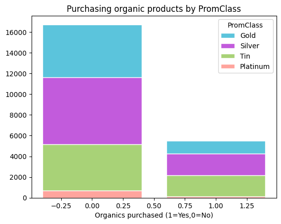

```python
# Explore the relationship between purchasing organic products and loyalty status
# 'TargetBuy' represent a customer purchased organic products (1) or not (0)

ax = sns.histplot(
    df,
    x='TargetBuy',
    hue='PromClass',
    multiple='stack',
    palette=['#24b1d1', '#ae24d1','#8bc34a','#ff867c','#ffd700'],
    # Add white borders to the bars.
    edgecolor='white',
    # Shrink the bars a bit so they don't touch.
    shrink=0.8
)

ax.set_title('Purchasing organic products by PromClass')
# Remove 'Count' ylabel.
ax.set_ylabel(None)
ax.set_xlabel('Organics purchased (1=Yes,0=No)')
```

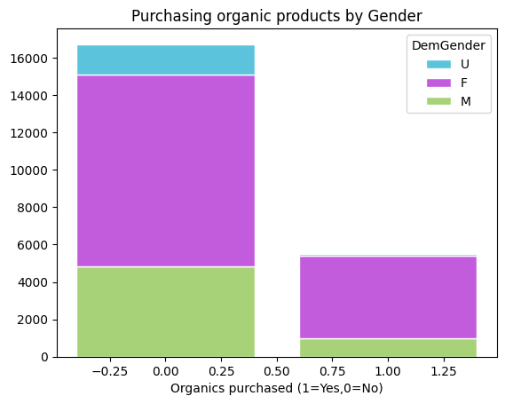

```python
# Explore the relationship between purchasing organic products and gender
# 'TargetBuy' represent a customer purchased organic products (1) or not (0)
ax = sns.histplot(
    df,
    x='TargetBuy',
    hue='DemGender',
    multiple='stack',
    palette=['#24b1d1', '#ae24d1','#8bc34a','#ff867c','#ffd700'],
    # Add white borders to the bars.
    edgecolor='white',
    # Shrink the bars a bit so they don't touch.
    shrink=0.8
)

ax.set_title('Purchasing organic products by Gender')
# Remove 'Count' ylabel.
ax.set_ylabel(None)
ax.set_xlabel('Organics purchased (1=Yes,0=No)')
```

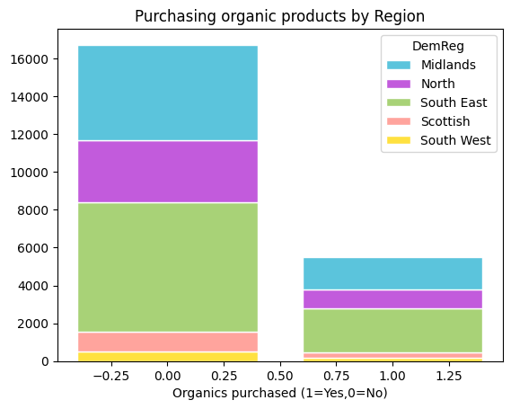

```python
# Explore the relationship between purchasing organic products and region
# 'TargetBuy' represent a customer purchased organic products (1) or not (0)
ax = sns.histplot(
    df,
    x='TargetBuy',
    hue='DemReg',
    multiple='stack',
    palette=['#24b1d1', '#ae24d1','#8bc34a','#ff867c','#ffd700'],
    # Add white borders to the bars.
    edgecolor='white',
    # Shrink the bars a bit so they don't touch.
    shrink=0.8
)

ax.set_title('Purchasing organic products by Region')
# Remove 'Count' ylabel.
ax.set_ylabel(None)
ax.set_xlabel('Organics purchased (1=Yes,0=No)')
```

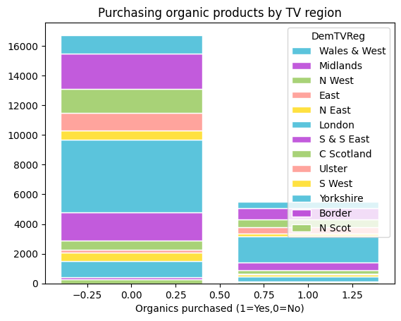

```python
# Explore the relationship between purchasing organic products and TV region
# 'TargetBuy' represent a customer purchased organic products (1) or not (0)
ax = sns.histplot(
    df,
    x='TargetBuy',
    hue='DemTVReg',
    multiple='stack',
    palette=['#24b1d1', '#ae24d1','#8bc34a','#ff867c','#ffd700'],
    # Add white borders to the bars.
    edgecolor='white',
    # Shrink the bars a bit so they don't touch.
    shrink=0.8
)

ax.set_title('Purchasing organic products by TV region')
# Remove 'Count' ylabel.
ax.set_ylabel(None)
ax.set_xlabel('Organics purchased (1=Yes,0=No)')
```

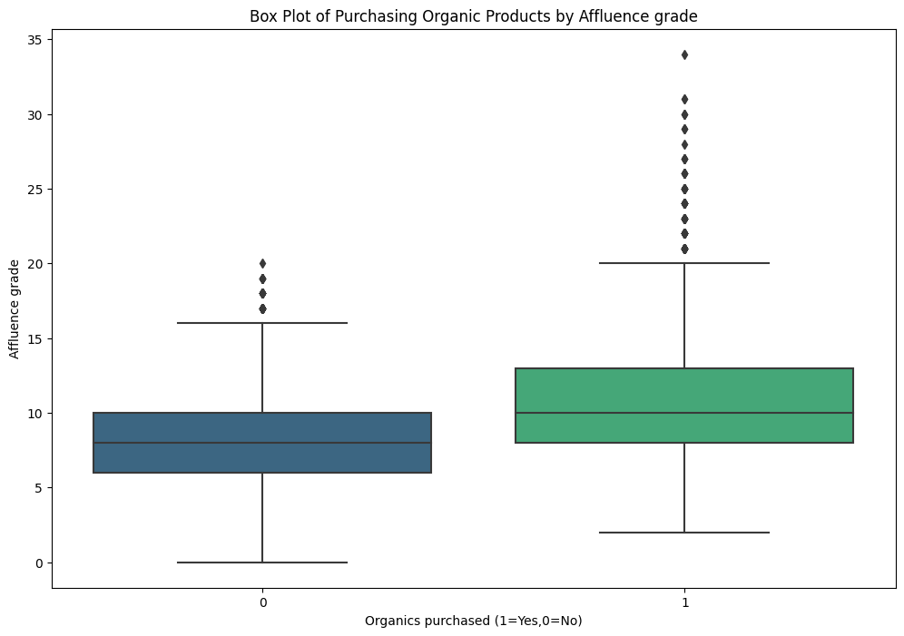

```python
# Explore the relationship between purchasing organic products and Affluence grade
# 'TargetBuy' represent a customer purchased organic products (1) or not (0)

import seaborn as sns
import matplotlib.pyplot as plt

# Create a Box Plot
plt.figure(figsize=(12, 8))
sns.boxplot(y='DemAffl', x='TargetBuy', data=df, palette='viridis')

plt.title('Box Plot of Purchasing Organic Products by Affluence grade')
plt.xlabel('Organics purchased (1=Yes,0=No)')
plt.ylabel('Affluence grade')
plt.show()
```

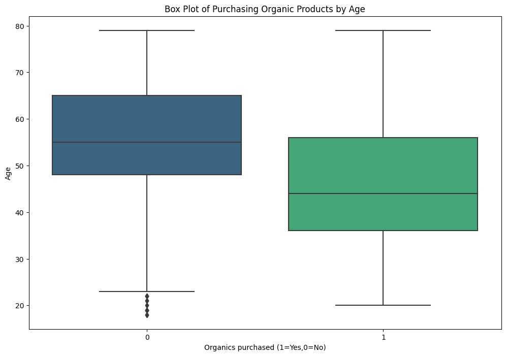

```python
# Explore the relationship between purchasing organic products and Age
# 'TargetBuy' represent a customer purchased organic products (1) or not (0)
import seaborn as sns
import matplotlib.pyplot as plt

# Assuming you have a DataFrame 'df' with columns 'TargetBuy' and 'DemClusterGroup'
# 'TargetBuy' should be a binary column indicating whether a customer purchased organic products (1) or not (0)

# Create a Box Plot
plt.figure(figsize=(12, 8))
sns.boxplot(y='DemAge', x='TargetBuy', data=df, palette='viridis')

plt.title('Box Plot of Purchasing Organic Products by Age')
plt.xlabel('Organics purchased (1=Yes,0=No)')
plt.ylabel('Age')
plt.show()
```

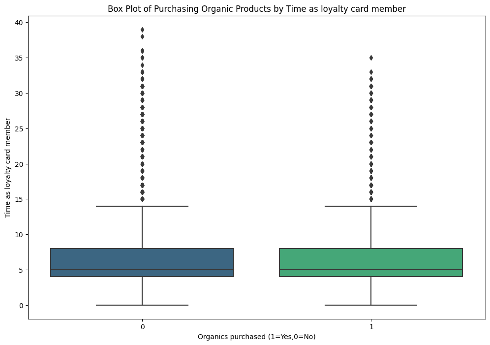

```python
# Explore the relationship between purchasing organic products and Time as loyalty card memeber
# 'TargetBuy' represent a customer purchased organic products (1) or not (0)
import seaborn as sns
import matplotlib.pyplot as plt

# Create a Box Plot
plt.figure(figsize=(12, 8))
sns.boxplot(y='PromTime', x='TargetBuy', data=df, palette='viridis')

plt.title('Box Plot of Purchasing Organic Products by Time as loyalty card member')
plt.xlabel('Organics purchased (1=Yes,0=No)')
plt.ylabel('Time as loyalty card member')
plt.show()
```

# MODEL 1: Full logistic regression model

```python
# split the data into training and testing sets
X = df.drop(['TargetBuy','TargetAmt','ID'], axis=1)
#Create dummy variables for nominal inputs
X = pd.get_dummies(X, columns=['DemClusterGroup', 'DemGender', 'DemReg', 'DemTVReg', 'PromClass'], drop_first=True)

y = df['TargetBuy']
X_train, X_test, y_train, y_test = train_test_split(X, y, test_size=0.3, random_state=42)

X_train.info()
y_train.info()
```

```
<class 'pandas.core.frame.DataFrame'>
Int64Index: 15556 entries, 5426 to 15795
Data columns (total 32 columns):
 #   Column                 Non-Null Count  Dtype
---  ------                 --------------  -----
 0   DemAffl                15556 non-null  float64
 1   DemAge                 15556 non-null  float64
 2   DemCluster             15556 non-null  float64
 3   PromSpend              15556 non-null  float64
 4   PromTime               15556 non-null  float64
 5   DemClusterGroup_B      15556 non-null  uint8
 6   DemClusterGroup_C      15556 non-null  uint8
 7   DemClusterGroup_D      15556 non-null  uint8
 8   DemClusterGroup_E      15556 non-null  uint8
 9   DemClusterGroup_F      15556 non-null  uint8
```

[output cut: 32 more lines]

## Full Logistic Regression Model Using statsmodels

Train the model on the training set - evaluate the model on both the training and test sets

```python
#Fit full logistic regression model to examine the significance of the terms
X = X_train
X = sm.add_constant(X)
y=y_train

logit_full = sm.Logit(y, X).fit()

#Print summary
print(logit_full.summary())
```

```
Optimization terminated successfully.
         Current function value: 0.449649
         Iterations 7
                           Logit Regression Results
==============================================================================
Dep. Variable:              TargetBuy   No. Observations:                15556
Model:                          Logit   Df Residuals:                    15527
Method:                           MLE   Df Model:                           28
Date:                Tue, 21 Nov 2023   Pseudo R-squ.:                  0.1967
Time:                        04:17:04   Log-Likelihood:                -6994.7
converged:                       True   LL-Null:                       -8707.9
Covariance Type:            nonrobust   LLR p-value:                     0.000
=========================================================================================
                            coef    std err          z      P>|z|      [0.025      0.975]
-----------------------------------------------------------------------------------------
const                    -0.3512      0.160     -2.198      0.028      -0.664      -0.038
DemAffl                   0.2476      0.007     35.381      0.000       0.234       0.261
DemAge                   -0.0536      0.002    -27.867      0.000      -0.057      -0.050
DemCluster                0.0034      0.008      0.448      0.654      -0.011       0.018
PromSpend             -4.487e-06    5.5e-06     -0.816      0.415   -1.53e-05    6.29e-06
PromTime                  0.0042      0.005      0.823      0.411      -0.006       0.014
DemClusterGroup_B        -0.0193      0.108     -0.178      0.859      -0.232       0.193
DemClusterGroup_C         0.0608      0.167      0.364      0.716      -0.266       0.388
DemClusterGroup_D        -0.0521      0.230     -0.226      0.821      -0.503       0.399
DemClusterGroup_E        -0.0747      0.299     -0.250      0.803      -0.661       0.511
DemClusterGroup_F        -0.0994      0.374     -0.265      0.791      -0.833       0.635
DemClusterGroup_U        -0.1658      0.554     -0.299      0.765      -1.252       0.920
DemGender_M              -0.7838      0.052    -15.007      0.000      -0.886      -0.681
DemGender_U              -1.7878      0.125    -14.269      0.000      -2.033      -1.542
DemReg_North             -0.0515   3.03e+06   -1.7e-08      1.000   -5.95e+06    5.95e+06
DemReg_Scottish          -0.1297      0.262     -0.496      0.620      -0.643       0.383
DemReg_South East        -0.0403   2.84e+06  -1.42e-08      1.000   -5.56e+06    5.56e+06
DemReg_South West         0.0661   8.75e+07   7.55e-10      1.000   -1.72e+08    1.72e+08
DemTVReg_C Scotland       0.0900      0.255      0.353      0.724      -0.409       0.589
DemTVReg_East             0.0360        nan        nan        nan         nan         nan
DemTVReg_London          -0.0141   2.84e+06  -4.96e-09      1.000   -5.56e+06    5.56e+06
DemTVReg_Midlands        -0.0164      0.070     -0.234      0.815      -0.153       0.121
DemTVReg_N East           0.0185   3.04e+06   6.09e-09      1.000   -5.97e+06    5.97e+06
DemTVReg_N Scot          -0.0627      0.298     -0.210      0.834      -0.648       0.522
DemTVReg_N West          -0.0263   3.04e+06  -8.64e-09      1.000   -5.97e+06    5.97e+06
DemTVReg_S & S East      -0.0263   2.84e+06  -9.27e-09      1.000   -5.56e+06    5.56e+06
DemTVReg_S West           0.0661    8.7e+07   7.59e-10      1.000    -1.7e+08     1.7e+08
DemTVReg_Ulster          -0.2117      0.228     -0.927      0.354      -0.659       0.236
DemTVReg_Wales & West    -0.0036        nan        nan        nan         nan         nan
DemTVReg_Yorkshire       -0.0438   3.04e+06  -1.44e-08      1.000   -5.97e+06    5.97e+06
PromClass_Platinum       -0.0855      0.178     -0.480      0.631      -0.434       0.263
PromClass_Silver         -0.0638      0.067     -0.959      0.337      -0.194       0.067
PromClass_Tin            -0.0286      0.075     -0.379      0.705      -0.176       0.119
=========================================================================================
```

## Evaluate Full Model on Training and Test Set

```python
# Generate predicted values for training set
pprob = logit_full.predict(X)

# Create predicted category for success using 50% cutoff
psuccess = (pprob > 0.5).astype(int)

# Add new variables to the training data set
X_train['p_success'] = psuccess
X_train['p_prob'] = pprob
X_train['y'] = y_train

X_train.info()


# Generate predicted values for test set

X_test = sm.add_constant(X_test)

pprob_test = logit_full.predict(X_test)

# Create predicted category for success using 50% cutoff
psuccess_test = (pprob_test > 0.5).astype(int)

# Add new variables to the response data set
X_test['p_success'] = psuccess_test
X_test['p_prob'] = pprob_test

X_test.info()
```

```
<class 'pandas.core.frame.DataFrame'>
Int64Index: 15556 entries, 5426 to 15795
Data columns (total 35 columns):
 #   Column                 Non-Null Count  Dtype
---  ------                 --------------  -----
 0   DemAffl                15556 non-null  float64
 1   DemAge                 15556 non-null  float64
 2   DemCluster             15556 non-null  float64
 3   PromSpend              15556 non-null  float64
 4   PromTime               15556 non-null  float64
 5   DemClusterGroup_B      15556 non-null  uint8
 6   DemClusterGroup_C      15556 non-null  uint8
 7   DemClusterGroup_D      15556 non-null  uint8
 8   DemClusterGroup_E      15556 non-null  uint8
 9   DemClusterGroup_F      15556 non-null  uint8
```

[output cut: 69 more lines]

Generate confusion matrices for training and test sets

```python
# Generate confusion matrix for training set
conf_matrix = confusion_matrix(psuccess, y_train)
print(conf_matrix)

# Generate confusion matrix for test set
conf_matrix = confusion_matrix(psuccess_test, y_test)
print(conf_matrix)
```

```
[[11092  2495]
 [  611  1358]]
[[4763 1022]
 [ 252  630]]
```

Create ROC curves for training and test sets

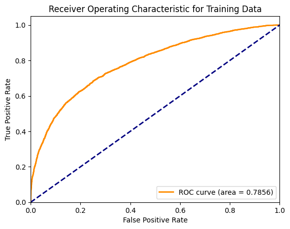

```python
# Generate ROC curve for training data
fpr, tpr, thresholds = roc_curve(y_train.cat.codes, pprob)
roc_auc = roc_auc_score(y_train.cat.codes, pprob)

# Plot ROC curve
plt.figure()
plt.plot(fpr, tpr, color='darkorange', lw=2, label=f'ROC curve (area = {roc_auc:.4f})')
plt.plot([0, 1], [0, 1], color='navy', lw=2, linestyle='--')
plt.xlim([0.0, 1.0])
plt.ylim([0.0, 1.05])
plt.xlabel('False Positive Rate')
plt.ylabel('True Positive Rate')
plt.title('Receiver Operating Characteristic for Training Data')
plt.legend(loc='lower right')
plt.show()
```

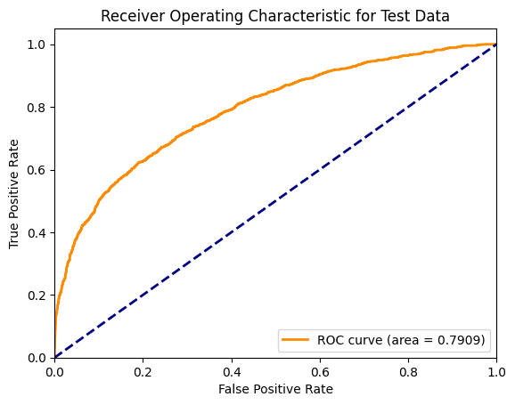

```python
# Generate ROC curve for test data
fpr, tpr, thresholds = roc_curve(y_test.cat.codes, pprob_test)
roc_auc = roc_auc_score(y_test.cat.codes, pprob_test)

# Plot ROC curve
plt.figure()
plt.plot(fpr, tpr, color='darkorange', lw=2, label=f'ROC curve (area = {roc_auc:.4f})')
plt.plot([0, 1], [0, 1], color='navy', lw=2, linestyle='--')
plt.xlim([0.0, 1.0])
plt.ylim([0.0, 1.05])
plt.xlabel('False Positive Rate')
plt.ylabel('True Positive Rate')
plt.title('Receiver Operating Characteristic for Test Data')
plt.legend(loc='lower right')
plt.show()
```

Compute Accuracy, Precision, Recall for training and test sets

```python
# calculate the accuracy, precision, and recall scores
acc_train = accuracy_score(y_train, psuccess)
prec_train = precision_score(y_train, psuccess)
rec_train = recall_score(y_train, psuccess)

# print the scores

print("Accuracy (Train) : {:.4f}".format(acc_train))
print("Precision (Train): {:.4f}".format(prec_train))
print("Recall (Train)  : {:.4f}".format(rec_train))
print("")

# calculate the accuracy, precision, and recall scores
acc_test = accuracy_score(y_test, psuccess_test)
prec_test = precision_score(y_test, psuccess_test)
rec_test = recall_score(y_test, psuccess_test)

# print the scores

print("Accuracy (Test) : {:.4f}".format(acc_test))
print("Precision (Test): {:.4f}".format(prec_test))
print("Recall (Test)  : {:.4f}".format(rec_test))
print("")
```

```
Accuracy (Train) : 0.8003
Precision (Train): 0.6897
Recall (Train)  : 0.3525

Accuracy (Test) : 0.8089
Precision (Test): 0.7143
Recall (Test)  : 0.3814
```

# MODEL 2: Fit a reduced logistic regression (from stepwise variable selection)

```python
# split the data into training and testing sets
Xr = df.drop(['TargetBuy','TargetAmt','ID'], axis=1)
Xr = df[['DemAffl','DemAge','DemGender']]
Xr = pd.get_dummies(Xr, columns=['DemGender'], drop_first=True)

yr = df['TargetBuy']
Xr_train, Xr_test, yr_train, yr_test = train_test_split(Xr, yr, test_size=0.3, random_state=42)

Xr_train.info()
yr_train.info()
```

```
<class 'pandas.core.frame.DataFrame'>
Int64Index: 15556 entries, 5426 to 15795
Data columns (total 4 columns):
 #   Column       Non-Null Count  Dtype
---  ------       --------------  -----
 0   DemAffl      15556 non-null  float64
 1   DemAge       15556 non-null  float64
 2   DemGender_M  15556 non-null  uint8
 3   DemGender_U  15556 non-null  uint8
dtypes: float64(2), uint8(2)
memory usage: 395.0 KB
<class 'pandas.core.series.Series'>
Int64Index: 15556 entries, 5426 to 15795
Series name: TargetBuy
Non-Null Count  Dtype
--------------  -----
15556 non-null  category
dtypes: category(1)
memory usage: 136.8 KB
```

```python
#Fit reduced (stepwise) logistic regression model to examine the significance of the terms
Xr = Xr_train
Xr = sm.add_constant(Xr)
yr=yr_train

logit_step = sm.Logit(yr, Xr).fit()

#Print summary
print(logit_step.summary())
```

```
Optimization terminated successfully.
         Current function value: 0.450099
         Iterations 7
                           Logit Regression Results
==============================================================================
Dep. Variable:              TargetBuy   No. Observations:                15556
Model:                          Logit   Df Residuals:                    15551
Method:                           MLE   Df Model:                            4
Date:                Tue, 21 Nov 2023   Pseudo R-squ.:                  0.1959
Time:                        04:18:01   Log-Likelihood:                -7001.7
converged:                       True   LL-Null:                       -8707.9
Covariance Type:            nonrobust   LLR p-value:                     0.000
===============================================================================
                  coef    std err          z      P>|z|      [0.025      0.975]
-------------------------------------------------------------------------------
const          -0.3314      0.109     -3.036      0.002      -0.545      -0.117
DemAffl         0.2472      0.007     35.396      0.000       0.234       0.261
DemAge         -0.0540      0.002    -30.955      0.000      -0.057      -0.051
DemGender_M    -0.7809      0.052    -14.980      0.000      -0.883      -0.679
DemGender_U    -1.7863      0.125    -14.273      0.000      -2.032      -1.541
===============================================================================
```

## Evaluate Reduced Model on Training and Test Set

```python
# Generate predicted values for training set
pprobr = logit_step.predict(Xr)

# Create predicted category for success using 50% cutoff
psuccessr = (pprobr > 0.5).astype(int)

# Add new variables to the training data set
Xr_train['p_success'] = psuccessr
Xr_train['p_prob'] = pprobr
Xr_train['y'] = yr_train

Xr_train.info()


# Generate predicted values for test set

Xr_test = sm.add_constant(Xr_test)

pprobr_test = logit_step.predict(Xr_test)

# Create predicted category for success using 50% cutoff
psuccessr_test = (pprobr_test > 0.5).astype(int)

# Add new variables to the response data set
Xr_test['p_success'] = psuccessr_test
Xr_test['p_prob'] = pprobr_test

Xr_test.info()
```

```
<class 'pandas.core.frame.DataFrame'>
Int64Index: 15556 entries, 5426 to 15795
Data columns (total 7 columns):
 #   Column       Non-Null Count  Dtype
---  ------       --------------  -----
 0   DemAffl      15556 non-null  float64
 1   DemAge       15556 non-null  float64
 2   DemGender_M  15556 non-null  uint8
 3   DemGender_U  15556 non-null  uint8
 4   p_success    15556 non-null  int64
 5   p_prob       15556 non-null  float64
 6   y            15556 non-null  category
dtypes: category(1), float64(3), int64(1), uint8(2)
memory usage: 653.4 KB
<class 'pandas.core.frame.DataFrame'>
Int64Index: 6667 entries, 1891 to 160
Data columns (total 7 columns):
 #   Column       Non-Null Count  Dtype
---  ------       --------------  -----
 0   const        6667 non-null   float64
 1   DemAffl      6667 non-null   float64
 2   DemAge       6667 non-null   float64
 3   DemGender_M  6667 non-null   uint8
 4   DemGender_U  6667 non-null   uint8
 5   p_success    6667 non-null   int64
 6   p_prob       6667 non-null   float64
dtypes: float64(4), int64(1), uint8(2)
memory usage: 325.5 KB
```

Generate confusion matrices for training and test sets

```python
# Generate confusion matrix for training set
conf_matrix = confusion_matrix(psuccessr, yr_train)
print(conf_matrix)

# Generate confusion matrix for test set
conf_matrix = confusion_matrix(psuccessr_test, yr_test)
print(conf_matrix)
```

```
[[11111  2522]
 [  592  1331]]
[[4772 1019]
 [ 243  633]]
```

Create ROC curves for training and test sets

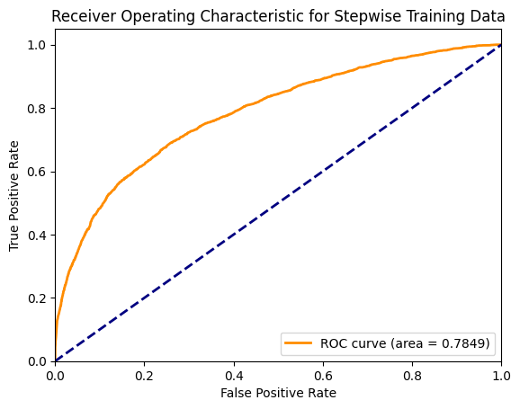

```python
# Generate ROC curve for training data
fpr, tpr, thresholds = roc_curve(yr_train.cat.codes, pprobr)
roc_auc = roc_auc_score(yr_train.cat.codes, pprobr)

# Plot ROC curve
plt.figure()
plt.plot(fpr, tpr, color='darkorange', lw=2, label=f'ROC curve (area = {roc_auc:.4f})')
plt.plot([0, 1], [0, 1], color='navy', lw=2, linestyle='--')
plt.xlim([0.0, 1.0])
plt.ylim([0.0, 1.05])
plt.xlabel('False Positive Rate')
plt.ylabel('True Positive Rate')
plt.title('Receiver Operating Characteristic for Stepwise Training Data')
plt.legend(loc='lower right')
plt.show()
```

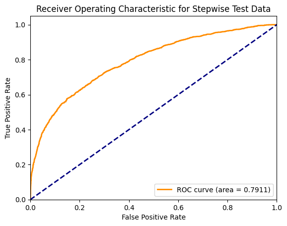

```python
# Generate ROC curve for test data
fpr, tpr, thresholds = roc_curve(yr_test.cat.codes, pprobr_test)
roc_auc = roc_auc_score(yr_test.cat.codes, pprobr_test)

# Plot ROC curve
plt.figure()
plt.plot(fpr, tpr, color='darkorange', lw=2, label=f'ROC curve (area = {roc_auc:.4f})')
plt.plot([0, 1], [0, 1], color='navy', lw=2, linestyle='--')
plt.xlim([0.0, 1.0])
plt.ylim([0.0, 1.05])
plt.xlabel('False Positive Rate')
plt.ylabel('True Positive Rate')
plt.title('Receiver Operating Characteristic for Stepwise Test Data')
plt.legend(loc='lower right')
plt.show()
```

Compute Accuracy, Precision, Recall for training and test sets

```python
# calculate the accuracy, precision, and recall scores
acc_trainr = accuracy_score(yr_train, psuccessr)
prec_trainr = precision_score(yr_train, psuccessr)
rec_trainr = recall_score(yr_train, psuccessr)

# print the scores

print("Accuracy (Train) : {:.4f}".format(acc_trainr))
print("Precision (Train): {:.4f}".format(prec_trainr))
print("Recall (Train)  : {:.4f}".format(rec_trainr))
print("")

# calculate the accuracy, precision, and recall scores
acc_testr = accuracy_score(yr_test, psuccessr_test)
prec_testr = precision_score(yr_test, psuccessr_test)
rec_testr = recall_score(yr_test, psuccessr_test)

# print the scores

print("Accuracy (Test) : {:.4f}".format(acc_testr))
print("Precision (Test): {:.4f}".format(prec_testr))
print("Recall (Test)  : {:.4f}".format(rec_testr))
print("")
```

```
Accuracy (Train) : 0.7998
Precision (Train): 0.6921
Recall (Train)  : 0.3454

Accuracy (Test) : 0.8107
Precision (Test): 0.7226
Recall (Test)  : 0.3832
```

# Model 3: sklearn implementation with Lasso L1 Regularization using c = 0.1

# Model 4: sklearn implementation with Lasso L1 Regularization usingand c = 0.01

# Model 5: sklearn implementation Ridge Regression L2 Regularization

```python
# split the data into training and testing sets
X2 = df.drop(['TargetBuy','TargetAmt','ID'], axis=1)
#Create dummy variables for nominal inputs
X2 = pd.get_dummies(X2, columns=['DemClusterGroup', 'DemGender', 'DemReg', 'DemTVReg', 'PromClass'], drop_first=True)

y2 = df['TargetBuy']
X2_train, X2_test, y2_train, y2_test = train_test_split(X2, y2, test_size=0.3, random_state=42)

X2_train.info()

y2_train.info()
```

```
<class 'pandas.core.frame.DataFrame'>
Int64Index: 15556 entries, 5426 to 15795
Data columns (total 32 columns):
 #   Column                 Non-Null Count  Dtype
---  ------                 --------------  -----
 0   DemAffl                15556 non-null  float64
 1   DemAge                 15556 non-null  float64
 2   DemCluster             15556 non-null  float64
 3   PromSpend              15556 non-null  float64
 4   PromTime               15556 non-null  float64
 5   DemClusterGroup_B      15556 non-null  uint8
 6   DemClusterGroup_C      15556 non-null  uint8
 7   DemClusterGroup_D      15556 non-null  uint8
 8   DemClusterGroup_E      15556 non-null  uint8
 9   DemClusterGroup_F      15556 non-null  uint8
```

[output cut: 32 more lines]

## Fit Logistic Regression Model 3 using L1 with c = 0.1

```python
# Create an Instance of Logistic Regression for LASSO Selection  using c = 0.1 and c = 0.01

lr_l1_1 = LogisticRegression(penalty='l1', solver='liblinear', C=0.1)


# fit the models to the training data
lr_l1_1.fit(X2_train, y2_train)
```

```
LogisticRegression(C=0.1, penalty='l1', solver='liblinear')
```

## Fit Logistic Regression Model 4 using L1 with c = 0.01

```python
lr_l1_01 = LogisticRegression(penalty='l1', solver='liblinear', C=0.01)
lr_l1_01.fit(X2_train, y2_train)
```

```
LogisticRegression(C=0.01, penalty='l1', solver='liblinear')
```

## Fit Logistic Regression Model 5 using L2

```python
# Create an Instance of Logistic Regression for Ridge Regression (L2 regularization)
lr_l2 = LogisticRegression(penalty='l2', solver='liblinear')


# fit the models to the training data
lr_l2.fit(X2_train, y2_train)
```

```
LogisticRegression(solver='liblinear')
```

```python
# function for model coefficents
def rpt_model_variables(model):
    # Get the intercept term
    intercept = model.intercept_

    # Access the coefficients (weights) of the model, i rounded them
    coefficients = np.round(model.coef_[0],decimals=4)

    # Create DataFrames for intercept and coefficients
    #df_intercept = pd.DataFrame({'feature': ['Intercept'], 'coefficient': [intercept[0]]})
    df_coefficients = pd.DataFrame({'feature': X2.columns, 'coefficient': coefficients})
    df_coefficients['abs_coefficient'] = df_coefficients['coefficient'].abs()
    df_coefficients.sort_values(by='abs_coefficient', ascending=False, inplace=True)

    # if you want to add intercept to table
    #df_model = pd.concat([df_intercept, df_coefficients]).reset_index(drop=True)

    # Print the DataFrame
    print(df_coefficients)

    return df_coefficients

df_coefficients1 = rpt_model_variables(lr_l1_1)
df_coefficients01 = rpt_model_variables(lr_l1_01)
df_coefficients2 = rpt_model_variables(lr_l2)
```

```
                  feature  coefficient  abs_coefficient
12            DemGender_U      -1.6353           1.6353
11            DemGender_M      -0.7537           0.7537
0                 DemAffl       0.2434           0.2434
1                  DemAge      -0.0542           0.0542
6       DemClusterGroup_C       0.0529           0.0529
30       PromClass_Silver      -0.0328           0.0328
13           DemReg_North      -0.0319           0.0319
15      DemReg_South East      -0.0285           0.0285
4                PromTime       0.0029           0.0029
16      DemReg_South West       0.0021           0.0021
25        DemTVReg_S West       0.0015           0.0015
2              DemCluster       0.0007           0.0007
10      DemClusterGroup_U       0.0000           0.0000
9       DemClusterGroup_F       0.0000           0.0000
```

[output cut: 84 more lines]

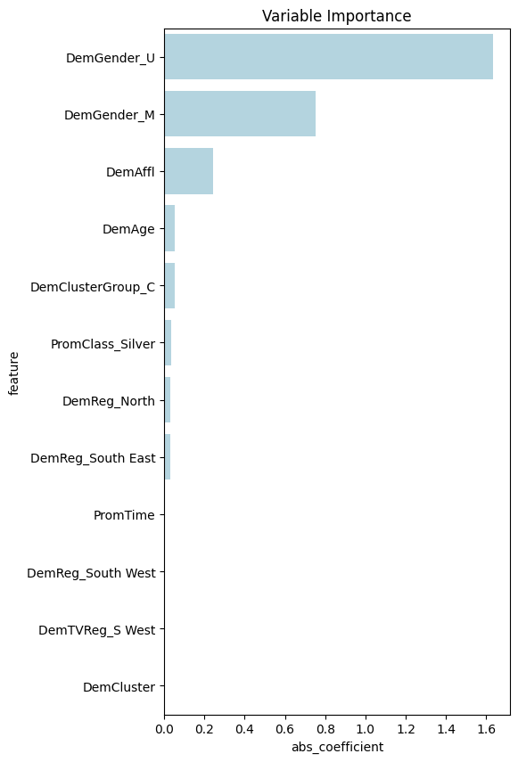

```
-- rejected --
 DemClusterGroup_U
 DemClusterGroup_F
 PromClass_Platinum
 DemTVReg_Yorkshire
 DemTVReg_Wales & West
 DemTVReg_Ulster
 DemTVReg_S & S East
 DemTVReg_N West
 DemTVReg_N Scot
 DemTVReg_N East
 DemTVReg_Midlands
 DemTVReg_London
 DemTVReg_East
 DemTVReg_C Scotland
 PromSpend
 DemClusterGroup_B
 DemReg_Scottish
 DemClusterGroup_D
 DemClusterGroup_E
 PromClass_Tin
```

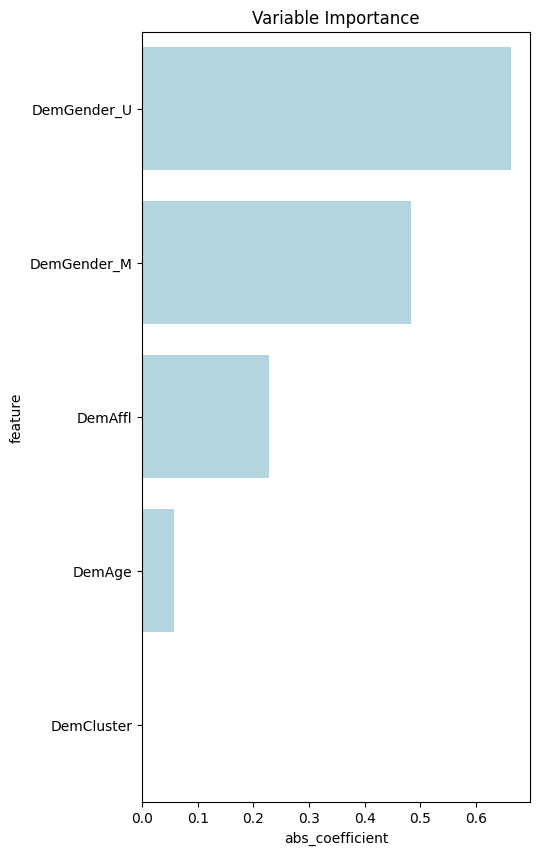

```
-- rejected --
 DemTVReg_N West
 DemTVReg_Midlands
 DemTVReg_N East
 DemTVReg_N Scot
 DemTVReg_S & S East
 DemTVReg_East
 DemTVReg_S West
 DemTVReg_Ulster
 DemTVReg_Wales & West
 DemTVReg_Yorkshire
 PromClass_Platinum
 PromClass_Silver
 DemTVReg_London
 DemReg_South West
 DemTVReg_C Scotland
 DemReg_South East
 DemReg_Scottish
 DemReg_North
 DemClusterGroup_U
 DemClusterGroup_F
 DemClusterGroup_E
 DemClusterGroup_D
 DemClusterGroup_C
 DemClusterGroup_B
 PromTime
 PromSpend
 PromClass_Tin
```

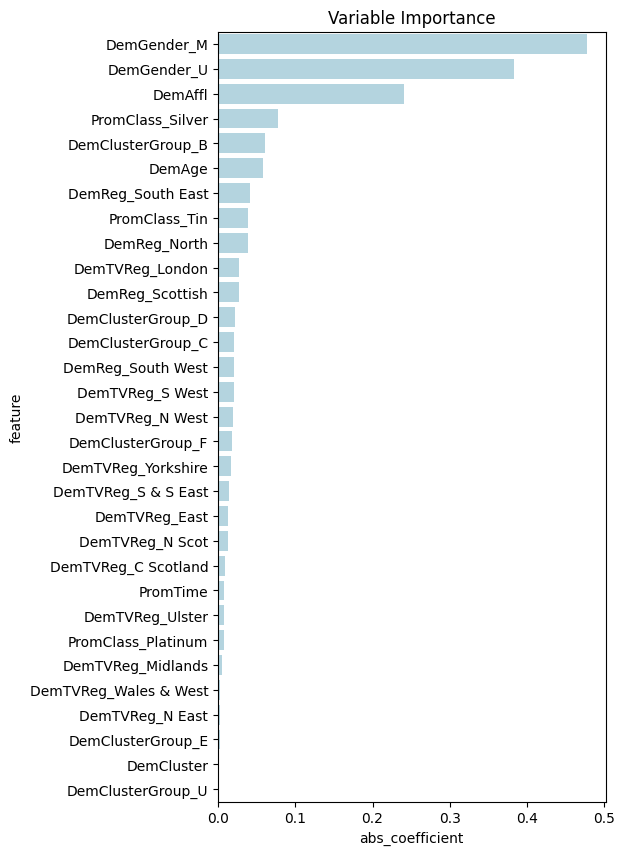

```
-- rejected --
 PromSpend
```

```python
# plot variable importance
def plot_variable_imp(df_coef):
  df_plt = df_coef[df_coef['abs_coefficient'] != 0]
  reject_vars = df_coef[df_coef['abs_coefficient'] == 0]['feature'].tolist()

  plt.figure(figsize=(5, 10))
  plt.title('Variable Importance')
  plt.xlabel('Coefficient')
  plt.ylabel('Feature')
  sns.barplot(data=df_plt,
                     y=df_plt['feature'],
                     x=df_plt['abs_coefficient'], color="lightblue")

  plt.show()
  print("-- rejected --")
  for i in reject_vars:
    print(f" {i}")

plot_variable_imp(df_coefficients1)
plot_variable_imp(df_coefficients01)
plot_variable_imp(df_coefficients2)
```

## Make Predictions on the training and testing data for each model

```python
# make predictions on the testing data
y_pred_train = lr_l1_1.predict(X2_train)
y_pred_test = lr_l1_1.predict(X2_test)
y_proba_train = lr_l1_1.predict_proba(X2_train)
y_proba_test = lr_l1_1.predict_proba(X2_test)

y_pred_train1 = lr_l1_01.predict(X2_train)
y_pred_test1 = lr_l1_01.predict(X2_test)
y_proba_train1 = lr_l1_01.predict_proba(X2_train)
y_proba_test1 = lr_l1_01.predict_proba(X2_test)

y_pred_train2 = lr_l2.predict(X2_train)
y_pred_test2 = lr_l2.predict(X2_test)
y_proba_train2 = lr_l2.predict_proba(X2_train)
y_proba_test2 = lr_l2.predict_proba(X2_test)
```

## Calculate Accuracy, Precision, Recall for each model on training and test set

Model 3: L1 with c=0.1

```python
# calculate the accuracy, precision, and recall scores
acc2_train = accuracy_score(y2_train, y_pred_train)
prec2_train = precision_score(y2_train, y_pred_train)
rec2_train = recall_score(y2_train, y_pred_train)
auc2_train = roc_auc_score(y2_train, y_proba_train[:,1])

# print the scores
print(" -- train set -- ")
print("Accuracy : {:.4f}".format(acc2_train))
print("Precision: {:.4f}".format(prec2_train))
print("Recall.  : {:.4f}".format(rec2_train))
print("AUC      : {:.4f}".format(auc2_train))
print("")

# calculate the accuracy, precision, and recall scores
acc2_test = accuracy_score(y2_test, y_pred_test)
prec2_test = precision_score(y2_test, y_pred_test)
rec2_test = recall_score(y2_test, y_pred_test)
auc2_test = roc_auc_score(y2_test, y_proba_test[:,1])

print(" -- test set -- ")
print("Accuracy : {:.4f}".format(acc2_test))
print("Precision: {:.4f}".format(prec2_test))
print("Recall.  : {:.4f}".format(rec2_test))
print("AUC      : {:.4f}".format(auc2_test))
```

```
 -- train set --
Accuracy : 0.8005
Precision: 0.6931
Recall.  : 0.3488
AUC      : 0.7850

 -- test set --
Accuracy : 0.8104
Precision: 0.7230
Recall.  : 0.3808
AUC      : 0.7909
```

Model 4: L1 with c=0.01

```python
# calculate the accuracy, precision, and recall scores
acc2_train1 = accuracy_score(y2_train, y_pred_train1)
prec2_train1 = precision_score(y2_train, y_pred_train1)
rec2_train1 = recall_score(y2_train, y_pred_train1)
auc2_train1 = roc_auc_score(y2_train, y_proba_train1[:,1])

# print the scores
print(" -- train set -- ")
print("Accuracy : {:.4f}".format(acc2_train1))
print("Precision: {:.4f}".format(prec2_train1))
print("Recall.  : {:.4f}".format(rec2_train1))
print("AUC      : {:.4f}".format(auc2_train1))
print("")

# calculate the accuracy, precision, and recall scores
acc2_test1 = accuracy_score(y2_test, y_pred_test1)
prec2_test1 = precision_score(y2_test, y_pred_test1)
rec2_test1 = recall_score(y2_test, y_pred_test1)
auc2_test1 = roc_auc_score(y2_test, y_proba_test1[:,1])

print(" -- test set -- ")
print("Accuracy : {:.4f}".format(acc2_test1))
print("Precision: {:.4f}".format(prec2_test1))
print("Recall.  : {:.4f}".format(rec2_test1))
print("AUC      : {:.4f}".format(auc2_test1))
```

```
 -- train set --
Accuracy : 0.8001
Precision: 0.7018
Recall.  : 0.3353
AUC      : 0.7781

 -- test set --
Accuracy : 0.8089
Precision: 0.7299
Recall.  : 0.3632
AUC      : 0.7837
```

L2 regularization

```python
# calculate the accuracy, precision, and recall scores
acc2_train2 = accuracy_score(y2_train, y_pred_train2)
prec2_train2 = precision_score(y2_train, y_pred_train2)
rec2_train2 = recall_score(y2_train, y_pred_train2)
auc2_train2 = roc_auc_score(y2_train, y_proba_train2[:,1])

# print the scores
print(" -- train set -- ")
print("Accuracy : {:.4f}".format(acc2_train2))
print("Precision: {:.4f}".format(prec2_train2))
print("Recall.  : {:.4f}".format(rec2_train2))
print("AUC      : {:.4f}".format(auc2_train2))
print("")

# calculate the accuracy, precision, and recall scores
acc2_test2 = accuracy_score(y2_test, y_pred_test2)
prec2_test2 = precision_score(y2_test, y_pred_test2)
rec2_test2 = recall_score(y2_test, y_pred_test2)
auc2_test2 = roc_auc_score(y2_test, y_proba_test2[:,1])

print(" -- test set -- ")
print("Accuracy : {:.4f}".format(acc2_test2))
print("Precision: {:.4f}".format(prec2_test2))
print("Recall.  : {:.4f}".format(rec2_test2))
print("AUC      : {:.4f}".format(auc2_test2))
```

```
 -- train set --
Accuracy : 0.7994
Precision: 0.6967
Recall.  : 0.3369
AUC      : 0.7762

 -- test set --
Accuracy : 0.8080
Precision: 0.7241
Recall.  : 0.3638
AUC      : 0.7807
```

# Model 6: Decision tree

```python
# split the data into training and testing sets
Xt1 = df.drop(['TargetBuy','TargetAmt','ID','DemCluster'], axis=1)
#Create dummy variables for nominal inputs
Xt1 = pd.get_dummies(Xt1, columns=['DemClusterGroup', 'DemGender', 'DemReg', 'DemTVReg', 'PromClass'], drop_first=True)
# Assuming your DataFrame is named df
Xt = Xt1.drop(['DemClusterGroup_U', 'DemTVReg_C Scotland'], axis=1)


yt = df['TargetBuy']
Xt_train, Xt_test, yt_train, yt_test = train_test_split(Xt, yt, test_size=0.3, random_state=42)

Xt_train.info()
yt_train.info()
```

```
<class 'pandas.core.frame.DataFrame'>
Int64Index: 15556 entries, 5426 to 15795
Data columns (total 29 columns):
 #   Column                 Non-Null Count  Dtype
---  ------                 --------------  -----
 0   DemAffl                15556 non-null  float64
 1   DemAge                 15556 non-null  float64
 2   PromSpend              15556 non-null  float64
 3   PromTime               15556 non-null  float64
 4   DemClusterGroup_B      15556 non-null  uint8
 5   DemClusterGroup_C      15556 non-null  uint8
 6   DemClusterGroup_D      15556 non-null  uint8
 7   DemClusterGroup_E      15556 non-null  uint8
 8   DemClusterGroup_F      15556 non-null  uint8
 9   DemGender_M            15556 non-null  uint8
 10  DemGender_U            15556 non-null  uint8
 11  DemReg_North           15556 non-null  uint8
 12  DemReg_Scottish        15556 non-null  uint8
 13  DemReg_South East      15556 non-null  uint8
 14  DemReg_South West      15556 non-null  uint8
 15  DemTVReg_East          15556 non-null  uint8
 16  DemTVReg_London        15556 non-null  uint8
 17  DemTVReg_Midlands      15556 non-null  uint8
 18  DemTVReg_N East        15556 non-null  uint8
 19  DemTVReg_N Scot        15556 non-null  uint8
 20  DemTVReg_N West        15556 non-null  uint8
 21  DemTVReg_S & S East    15556 non-null  uint8
 22  DemTVReg_S West        15556 non-null  uint8
 23  DemTVReg_Ulster        15556 non-null  uint8
 24  DemTVReg_Wales & West  15556 non-null  uint8
 25  DemTVReg_Yorkshire     15556 non-null  uint8
 26  PromClass_Platinum     15556 non-null  uint8
 27  PromClass_Silver       15556 non-null  uint8
 28  PromClass_Tin          15556 non-null  uint8
dtypes: float64(4), uint8(25)
memory usage: 987.4 KB
<class 'pandas.core.series.Series'>
Int64Index: 15556 entries, 5426 to 15795
Series name: TargetBuy
Non-Null Count  Dtype
--------------  -----
15556 non-null  category
dtypes: category(1)
memory usage: 136.8 KB
```

## Decision Tree

We will use 3 parameters to control the growth of the tree

- **max_depth** determines the maximum number of levels for the tree. Smaller values help to prevent overfitting. Default value = None
- **min_samples_leaf** determines the minimum number of observations that must remain in a leaf. If a split leaves fewer than this number of observations, the split cannot be performed. Larger values help to prevent overfitting. Default value = 1.
- **ccp_alpha** is the cost complexity parameter and can be used for post-pruning the tree to help prevent overfitting. Default value = 0. Larger values yield a smaller tree.

```python
# create an instance of a decision tree classifier

dt = DecisionTreeClassifier(max_depth =6, min_samples_leaf=20, ccp_alpha = 0)

# fit the model to the training data
dt.fit(Xt_train, yt_train)
```

```
DecisionTreeClassifier(ccp_alpha=0, max_depth=6, min_samples_leaf=20)
```

## Visualize Tree

```python
from sklearn.tree import DecisionTreeClassifier, export_graphviz
import graphviz
# visualize the decision tree
dot_data = export_graphviz(dt, filled=True, rounded=True, feature_names=Xt.columns, class_names=['0', '1'])
graph = graphviz.Source(dot_data)
graph.render("decision_tree")
```

```
'decision_tree.pdf'
```

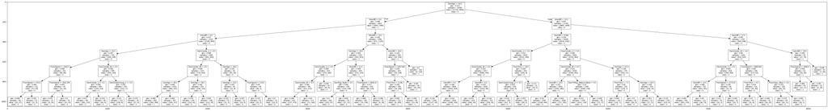

```python
export_graphviz(dt,
                'tree.dot',
                class_names=['0','1'],
                feature_names = Xt_train.columns)
! dot -Tpng tree.dot -o tree.png

import matplotlib.pyplot as plt
import cv2
%matplotlib inline
img = cv2.imread('tree.png')
plt.figure(figsize = (80, 160))
plt.imshow(img)
```

## Make Predictions on the training and test data

```python
# make predictions on the training and test data
yt_pred_train = dt.predict(Xt_train)
yt_pred_test = dt.predict(Xt_test)

yt_prob_train = dt.predict_proba(Xt_train)
yt_prob_test = dt.predict_proba(Xt_test)
```

## Assess Model on Training and Test data

```python
# calculate the accuracy, precision, and recall scores
acc_train = accuracy_score(yt_train, yt_pred_train)
prec_train = precision_score(yt_train, yt_pred_train)
rec_train = recall_score(yt_train, yt_pred_train)

# print the scores
print(" -- train set -- ")
print("Accuracy : {:.4f}".format(acc_train))
print("Precision: {:.4f}".format(prec_train))
print("Recall.  : {:.4f}".format(rec_train))
print("")

# calculate the accuracy, precision, and recall scores
acc_test = accuracy_score(yt_test, yt_pred_test)
prec_test = precision_score(yt_test, yt_pred_test)
rec_test = recall_score(yt_test, yt_pred_test)

print(" -- test set -- ")
print("Accuracy : {:.4f}".format(acc_test))
print("Precision: {:.4f}".format(prec_test))
print("Recall.  : {:.4f}".format(rec_test))
```

```
 -- train set --
Accuracy : 0.8091
Precision: 0.6991
Recall.  : 0.4023

 -- test set --
Accuracy : 0.8095
Precision: 0.6985
Recall.  : 0.4068
```

## Generate a confusion matrix for the training and test data

```python
# confusion matrix
conf_matrix = confusion_matrix(yt_pred_train, yt_train)
print(conf_matrix)

# Generate confusion matrix for test set
conf_matrix = confusion_matrix(yt_pred_test, yt_test)
print(conf_matrix)
```

```
[[11036  2303]
 [  667  1550]]
[[4725  980]
 [ 290  672]]
```

## Generate ROC curves for training and test data

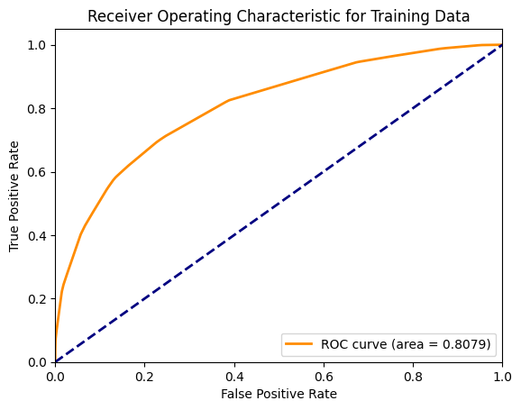

```python
# Generate ROC curve for training data

fpr, tpr, thresholds = roc_curve(yt_train.cat.codes, yt_prob_train[:,1])
roc_auc = roc_auc_score(yt_train.cat.codes, yt_prob_train[:,1])

# Plot ROC curve
plt.figure()
plt.plot(fpr, tpr, color='darkorange', lw=2, label=f'ROC curve (area = {roc_auc:.4f})')
plt.plot([0, 1], [0, 1], color='navy', lw=2, linestyle='--')
plt.xlim([0.0, 1.0])
plt.ylim([0.0, 1.05])
plt.xlabel('False Positive Rate')
plt.ylabel('True Positive Rate')
plt.title('Receiver Operating Characteristic for Training Data')
plt.legend(loc='lower right')
plt.show()
```

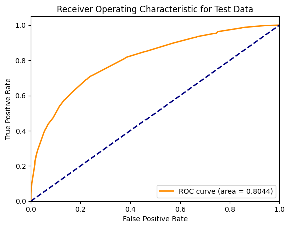

```python
# Generate ROC curve for test data
fpr, tpr, thresholds = roc_curve(yt_test.cat.codes, yt_prob_test[:,1])
roc_auc = roc_auc_score(yt_test.cat.codes, yt_prob_test[:,1])

# Plot ROC curve
plt.figure()
plt.plot(fpr, tpr, color='darkorange', lw=2, label=f'ROC curve (area = {roc_auc:.4f})')
plt.plot([0, 1], [0, 1], color='navy', lw=2, linestyle='--')
plt.xlim([0.0, 1.0])
plt.ylim([0.0, 1.05])
plt.xlabel('False Positive Rate')
plt.ylabel('True Positive Rate')
plt.title('Receiver Operating Characteristic for Test Data')
plt.legend(loc='lower right')
plt.show()
```

## Print feature importance for the tree

```
    importance                feature
1     0.525311                 DemAge
0     0.367290                DemAffl
9     0.048411            DemGender_M
10    0.045872            DemGender_U
2     0.006978              PromSpend
3     0.002215               PromTime
11    0.001330           DemReg_North
5     0.001147      DemClusterGroup_C
27    0.000892       PromClass_Silver
24    0.000501  DemTVReg_Wales & West
6     0.000054      DemClusterGroup_D
26    0.000000     PromClass_Platinum
25    0.000000     DemTVReg_Yorkshire
19    0.000000        DemTVReg_N Scot
23    0.000000        DemTVReg_Ulster
22    0.000000        DemTVReg_S West
21    0.000000    DemTVReg_S & S East
20    0.000000        DemTVReg_N West
14    0.000000      DemReg_South West
18    0.000000        DemTVReg_N East
17    0.000000      DemTVReg_Midlands
16    0.000000        DemTVReg_London
15    0.000000          DemTVReg_East
13    0.000000      DemReg_South East
12    0.000000        DemReg_Scottish
8     0.000000      DemClusterGroup_F
7     0.000000      DemClusterGroup_E
4     0.000000      DemClusterGroup_B
28    0.000000          PromClass_Tin
```

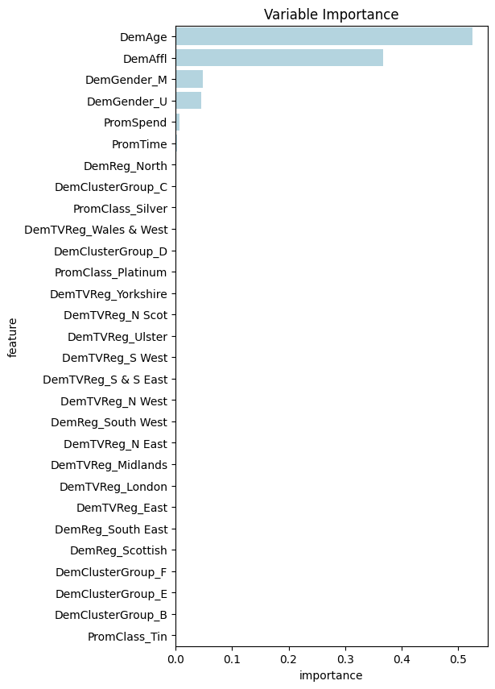

```python
#calculate feature importance
tree_imp = dt.feature_importances_

#create a data frame with feature names

# creating a list of column names
column_values = ['importance']

# creating the dataframe
df = pd.DataFrame(data = tree_imp,
                  columns = column_values)
df['feature']=Xt.columns

#sort data so features with largest importance values are at the top
df2 = df.sort_values(by=['importance'], ascending=False)

print(df2)

#Create variable importance plot
plt.figure(figsize=(5, 10))
plt.title('Variable Importance')
plt.xlabel('Importance')
plt.ylabel('Feature')
sns.barplot(data=df2,
            y=df2['feature'],
            x=df2['importance'], color="lightblue")

plt.show()
```

# Score New Customers

Load new customer data into a data frame

```python
# load the data into a pandas dataframe

data_path = '/content/drive/My Drive/Data/New_organics-1.csv'
dfnew = pd.read_csv(data_path)

# preview data
dfnew.info()
dfnew.head
print(dfnew)
```

```
<class 'pandas.core.frame.DataFrame'>
RangeIndex: 150 entries, 0 to 149
Data columns (total 11 columns):
 #   Column           Non-Null Count  Dtype
---  ------           --------------  -----
 0   ID               150 non-null    int64
 1   DemAffl          150 non-null    int64
 2   DemAge           150 non-null    int64
 3   DemCluster       150 non-null    int64
 4   DemClusterGroup  150 non-null    object
 5   DemGender        150 non-null    object
 6   DemReg           150 non-null    object
 7   DemTVReg         150 non-null    object
 8   PromClass        150 non-null    object
 9   PromSpend        150 non-null    float64
```

[output cut: 30 more lines]

Preprocess the new data so that it matches the structure of the data used to train the model

```python
dfnew1 = pd.get_dummies(dfnew, columns=['DemClusterGroup', 'DemGender', 'DemReg', 'DemTVReg', 'PromClass'], drop_first=True)
dfnew1.info()

dfnew1 = dfnew1.drop(['ID','DemCluster'], axis=1)
```

```
<class 'pandas.core.frame.DataFrame'>
RangeIndex: 150 entries, 0 to 149
Data columns (total 31 columns):
 #   Column                 Non-Null Count  Dtype
---  ------                 --------------  -----
 0   ID                     150 non-null    int64
 1   DemAffl                150 non-null    int64
 2   DemAge                 150 non-null    int64
 3   DemCluster             150 non-null    int64
 4   PromSpend              150 non-null    float64
 5   PromTime               150 non-null    int64
 6   DemClusterGroup_B      150 non-null    uint8
 7   DemClusterGroup_C      150 non-null    uint8
 8   DemClusterGroup_D      150 non-null    uint8
 9   DemClusterGroup_E      150 non-null    uint8
```

[output cut: 23 more lines]

"Score" the new data

```python
# make predictions on the training and test data
Scored_class = dt.predict(dfnew1)
Scored_probs = dt.predict_proba(dfnew1)

dfnew1['organics_purchased'] = Scored_class
dfnew1['prob_organics_purchased']=Scored_probs[:,1]

print(dfnew1)
```

```
     DemAffl  DemAge  PromSpend  PromTime  DemClusterGroup_B  \
0          6      46       0.01         8                  0
1         10      39       0.01         5                  1
2          7      75    4000.00         7                  1
3          7      72    1250.00        23                  1
4          7      43       0.01         5                  0
..       ...     ...        ...       ...                ...
145        3      59   12000.00         4                  1
146        8      69   14400.00         8                  0
147        7      27       0.01         4                  0
148       10      63    3000.00         7                  1
149       18      41       0.01         5                  0

     DemClusterGroup_C  DemClusterGroup_D  DemClusterGroup_E  \
0                    0                  1                  0
```

[output cut: 64 more lines]

```python
## Make a file contain the scores for the new customers
dfnew['organics_purchased'] = Scored_class
dfnew['prob_organics_purchased']=Scored_probs[:,1]

print(dfnew)
```

```
      ID  DemAffl  DemAge  DemCluster DemClusterGroup DemGender      DemReg  \
0      1        6      46          27               D         F  South East
1      2       10      39          12               B         M    Midlands
2      3        7      75          12               B         M    Midlands
3      4        7      72          12               B         F    Midlands
4      5        7      43          53               F         M       North
..   ...      ...     ...         ...             ...       ...         ...
145  146        3      59          12               B         F    Midlands
146  147        8      69          16               C         M  South East
147  158        7      27          52               F         F  South East
148  149       10      63          14               B         M  South East
149  150       18      41          35               D         F       North

    DemTVReg PromClass  PromSpend  PromTime  organics_purchased  \
0     London       Tin       0.01         8                   0
```

[output cut: 25 more lines]

```python
# Saving the updated DataFrame to a CSV file
output_file_path = '/content/drive/My Drive/Data/new_organics.csv'  # Path to save the new CSV file
dfnew.to_csv(output_file_path, index=False)  # Saving the DataFrame to a CSV file without index
```